# Summary of data for LLSIMBUM by trip for Blue marlin (Makaira nigricans), 2025-11-06

### Summary Tables

Table 1. Observed and unobserved effort by trips.

| Source | Sample units | Total effort | Proportion units | Proportion effort |
| --- | --- | --- | --- | --- |
| logbook | 7360 | 369417.52 | 1.000 | 1.000 |
| observer | 362 | 17599.82 | 0.049 | 0.048 |

Table 2. Input data summary for each year. For detailed information on each column see Appendix in User Guide.

| Year | Eff | Units | OCat | OEff | OUnit | CPUE | CPse | Out | Pos | OCatS | OEffS | Cov | PFrac | EFrac | UFrac | Cat | Cse |
| --- | --- | --- | --- | --- | --- | --- | --- | --- | --- | --- | --- | --- | --- | --- | --- | --- | --- |
| 2011 | 54272 | 1096 | 191 | 2996 | 53 | 0.08 | 0.01 | 0 | 37 | 5 | 54 | 168 | 0.70 | 0.06 | 0.05 | 3459 | 584 |
| 2012 | 55771 | 1079 | 127 | 2857 | 55 | 0.05 | 0.01 | 0 | 40 | 2 | 40 | 13 | 0.73 | 0.05 | 0.05 | 2479 | 393 |
| 2013 | 47228 | 920 | 95 | 1877 | 44 | 0.04 | 0.01 | 0 | 20 | 6 | 31 | 136 | 0.45 | 0.04 | 0.05 | 2390 | 754 |
| 2014 | 45602 | 867 | 73 | 2238 | 45 | 0.02 | 0.01 | 0 | 18 | 3 | 36 | 60 | 0.40 | 0.05 | 0.05 | 1487 | 289 |
| 2015 | 40476 | 836 | 52 | 1761 | 37 | 0.02 | 0.01 | 0 | 15 | 3 | 28 | 40 | 0.41 | 0.04 | 0.04 | 1195 | 293 |
| 2016 | 38227 | 783 | 79 | 1871 | 39 | 0.05 | 0.02 | 0 | 24 | 3 | 28 | 15 | 0.62 | 0.05 | 0.05 | 1614 | 386 |
| 2017 | 42997 | 850 | 90 | 2007 | 43 | 0.04 | 0.01 | 0 | 20 | 5 | 23 | 43 | 0.47 | 0.05 | 0.05 | 1928 | 620 |
| 2018 | 44844 | 929 | 89 | 1991 | 46 | 0.04 | 0.01 | 0 | 31 | 3 | 34 | 103 | 0.67 | 0.04 | 0.05 | 2004 | 338 |

### Logbook vs. observer effort figures

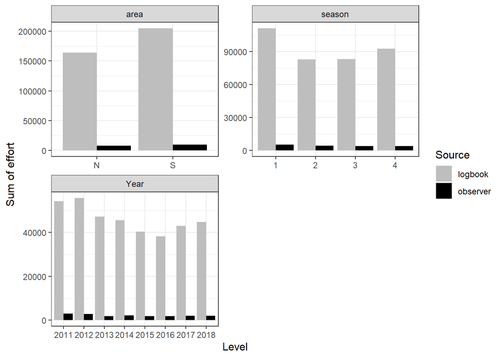

Figure 1. Total Effort by factor levels, observed and total.

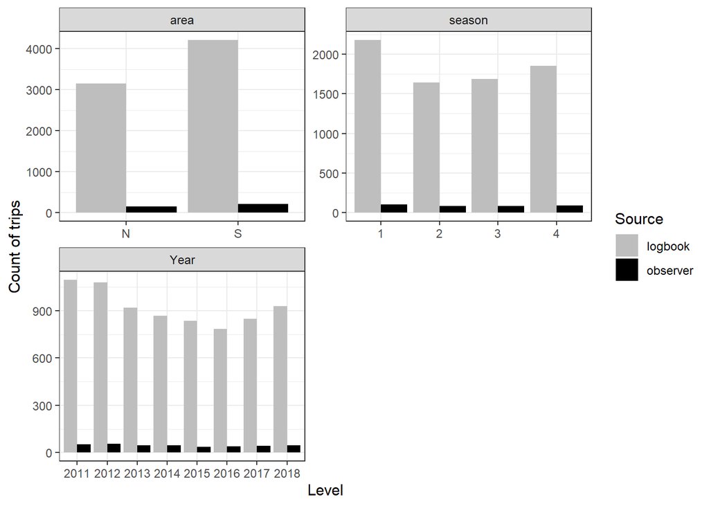

Figure 2. Count of trips by factor levels, observed and total.

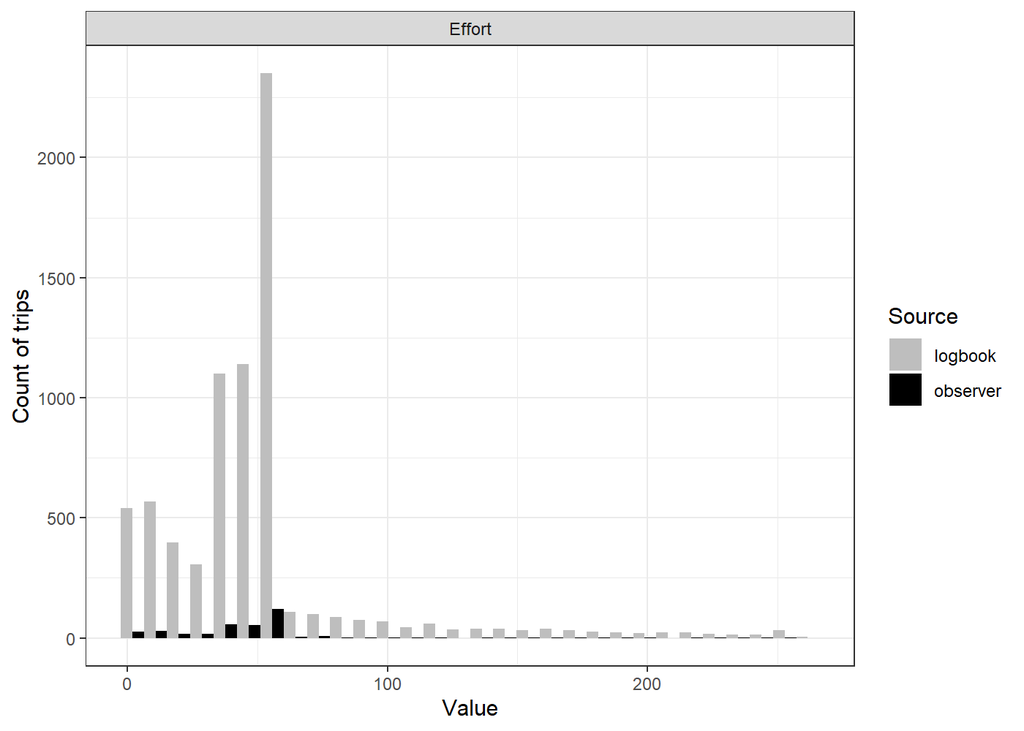

Figure 3. Effort across numerical variables.

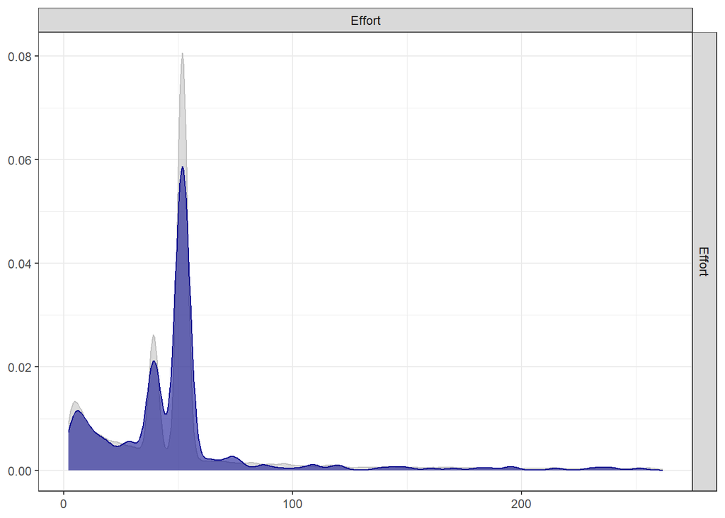

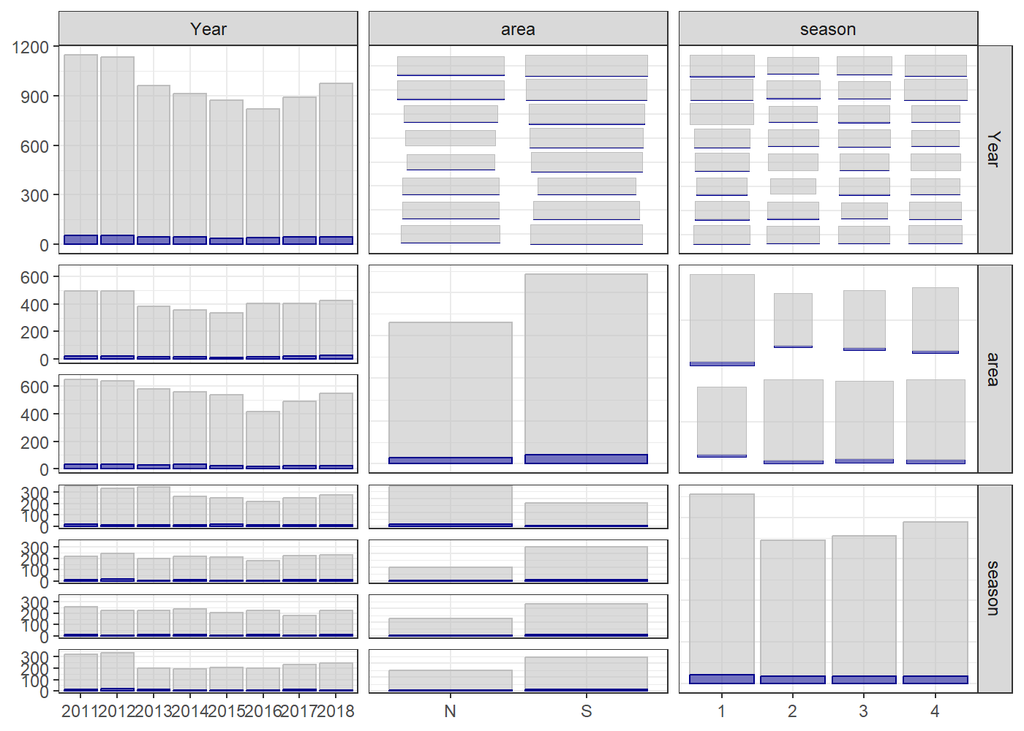

Figure 5. Effort across pairs of categorical variables. Grey: logbook data; Blue: observer data.

### Presence and absence of Blue marlin in observer data

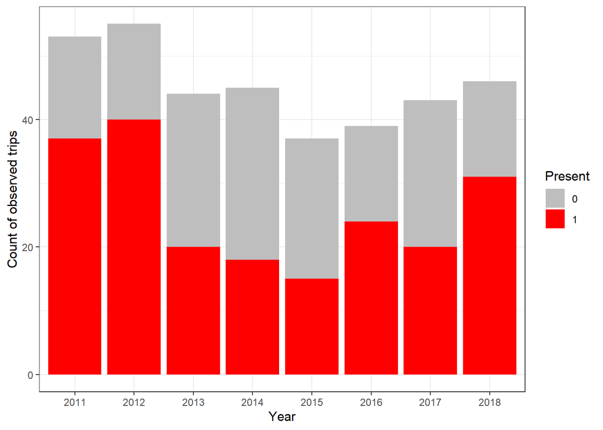

Figure 6. Presence and absence of Blue marlin in each year.

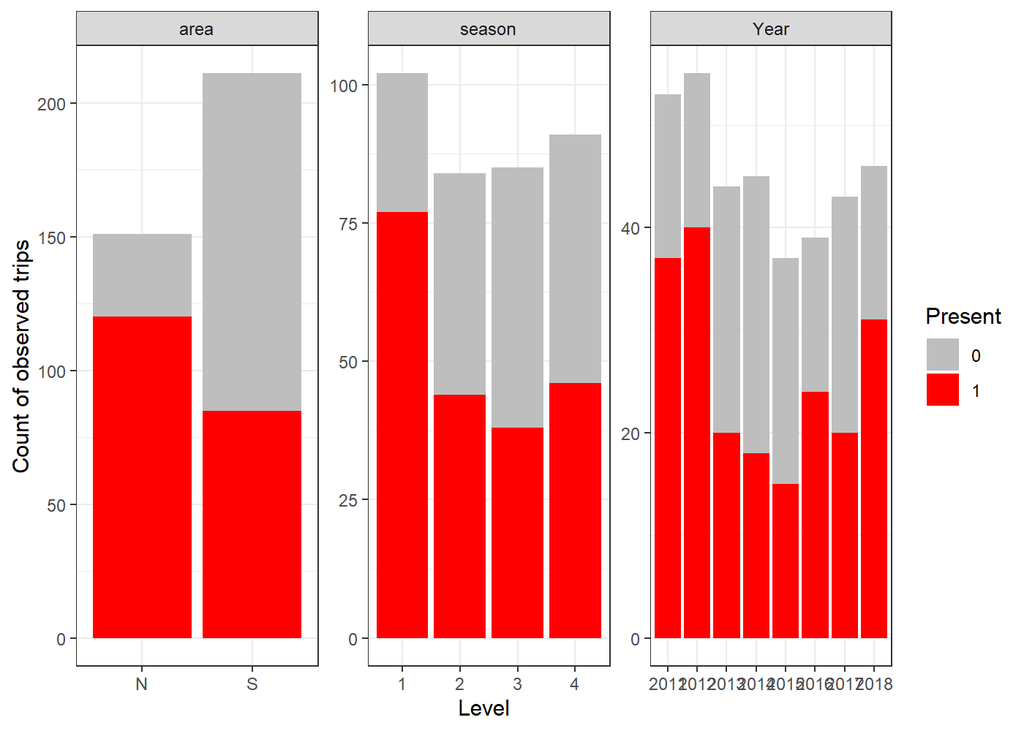

Figure 7. Presence and absence of Blue marlin across factor variables.

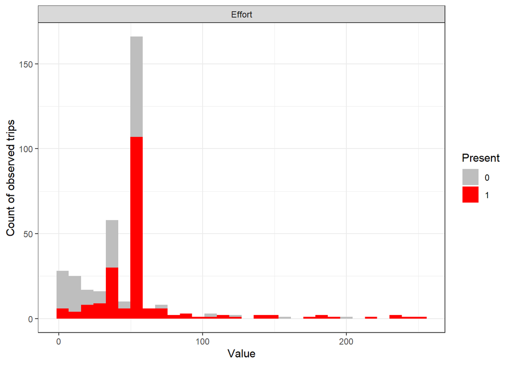

Figure 8. Presence and absence of Blue marlin across numerical variables.

### Total catch of Blue marlin in observer data

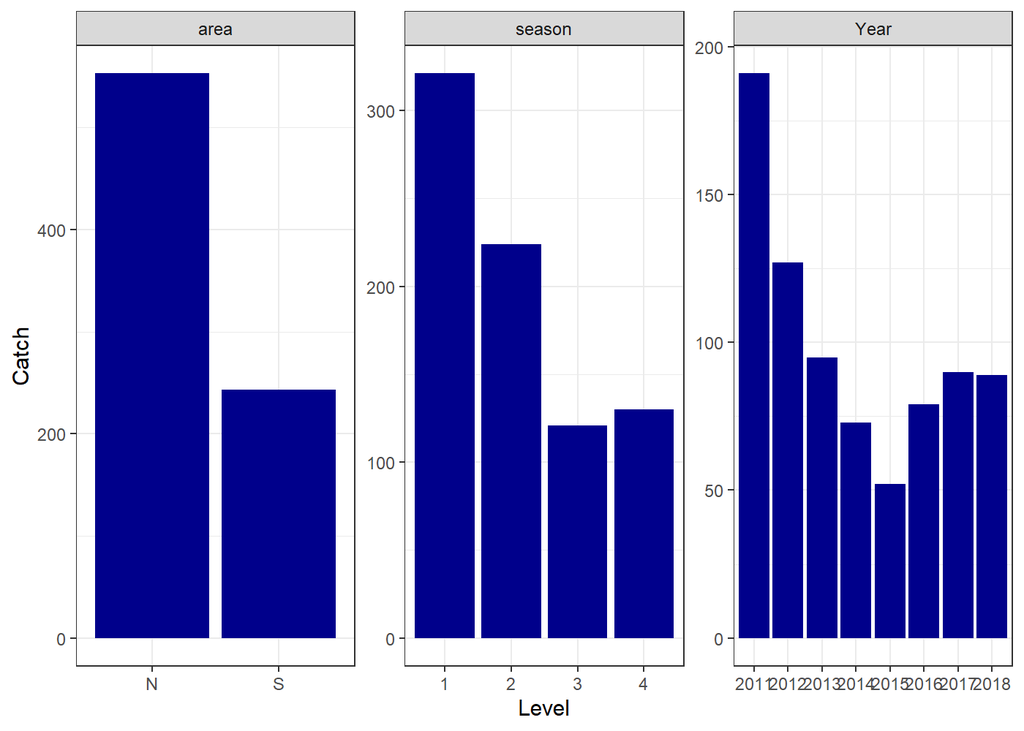

Figure 9. Observed total catch of Blue marlin by factor levels.

### Catch per sample unit of Blue marlin in observer data

Figure 10. Observed Catch histogram for Blue marlin.

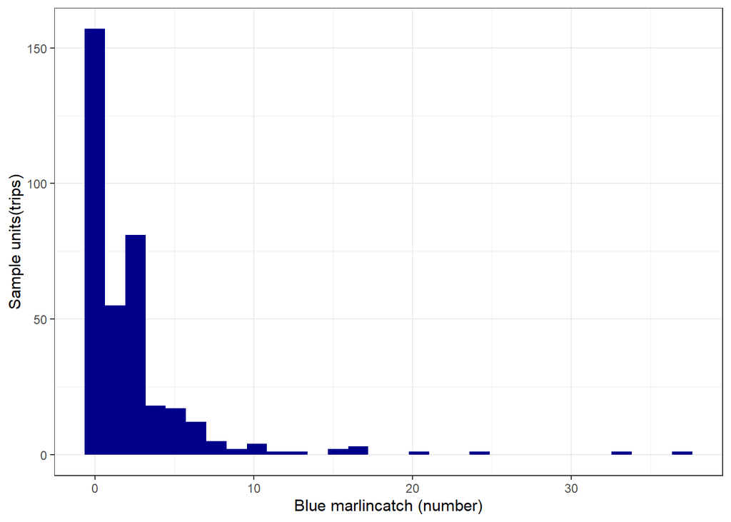

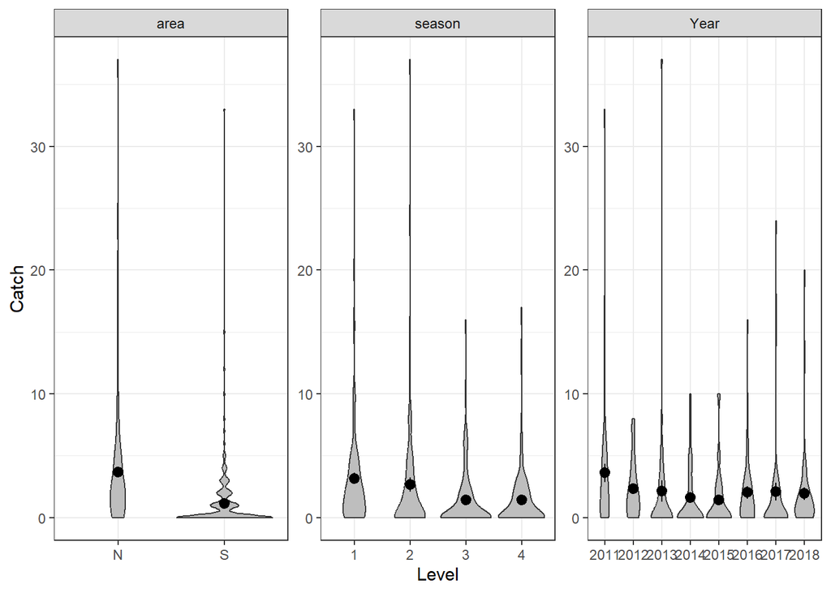

Figure 11. Observed Catch per trips of Blue marlin by factor levels.

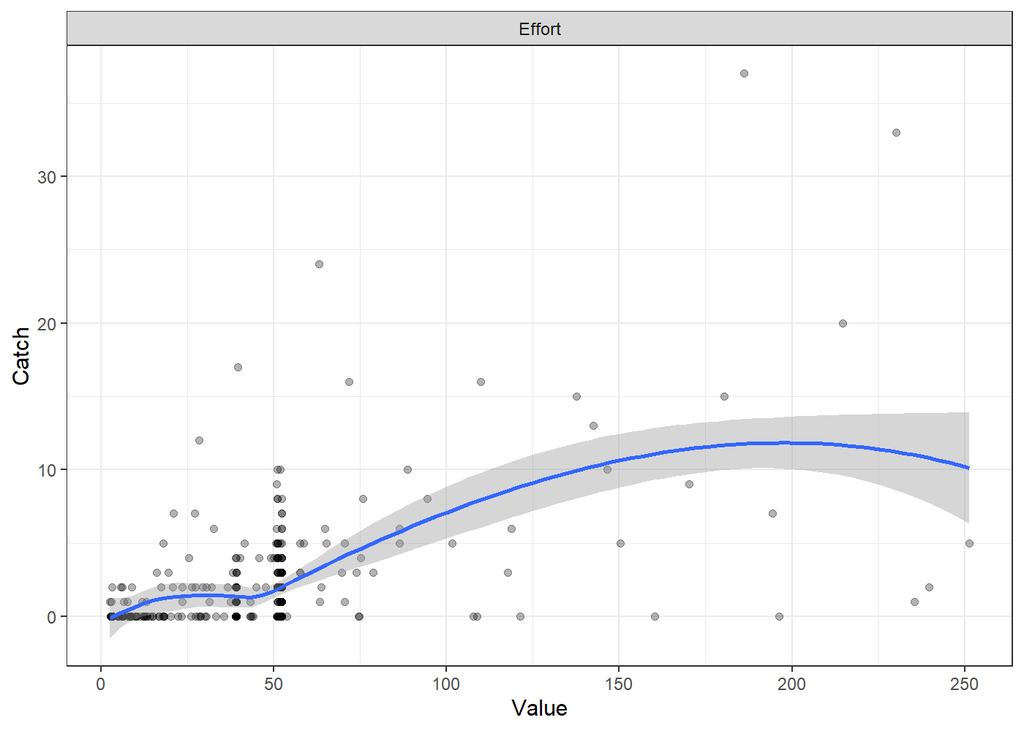

Figure 12. Observed Catch per trips of Blue marlin across numerical variables.

### CPUE of Blue marlin in observer data

Figure 13. Observed CPUE histogram for Blue marlin.

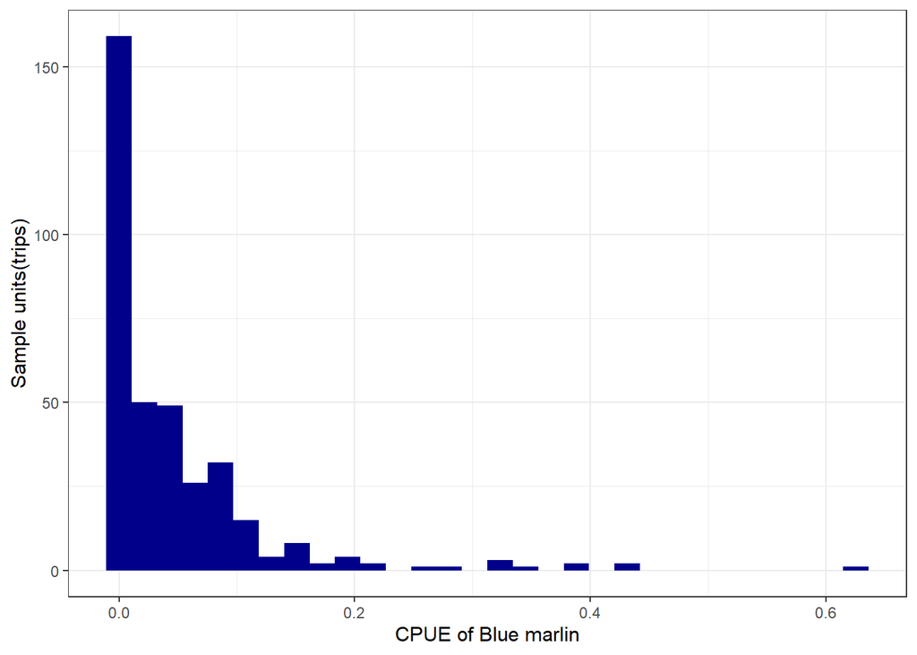

Figure 14. Log of Observed CPUE plus a constant histogram for Blue marlin.

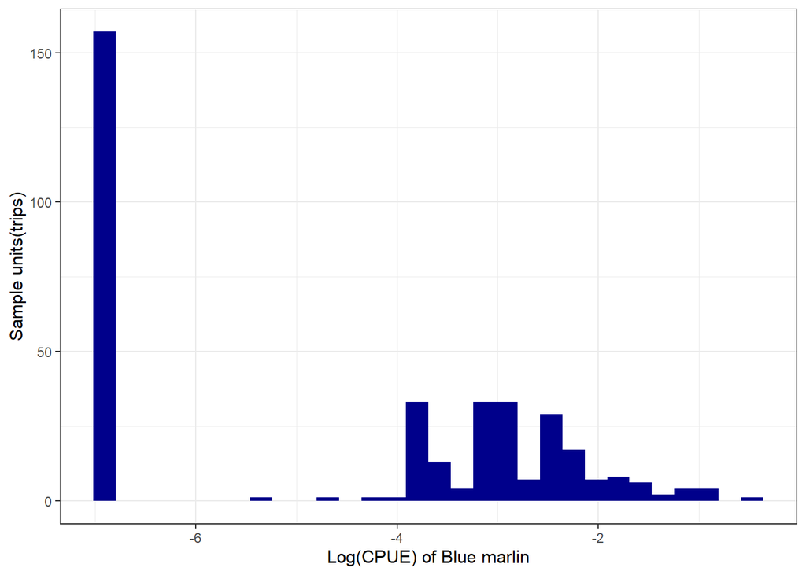

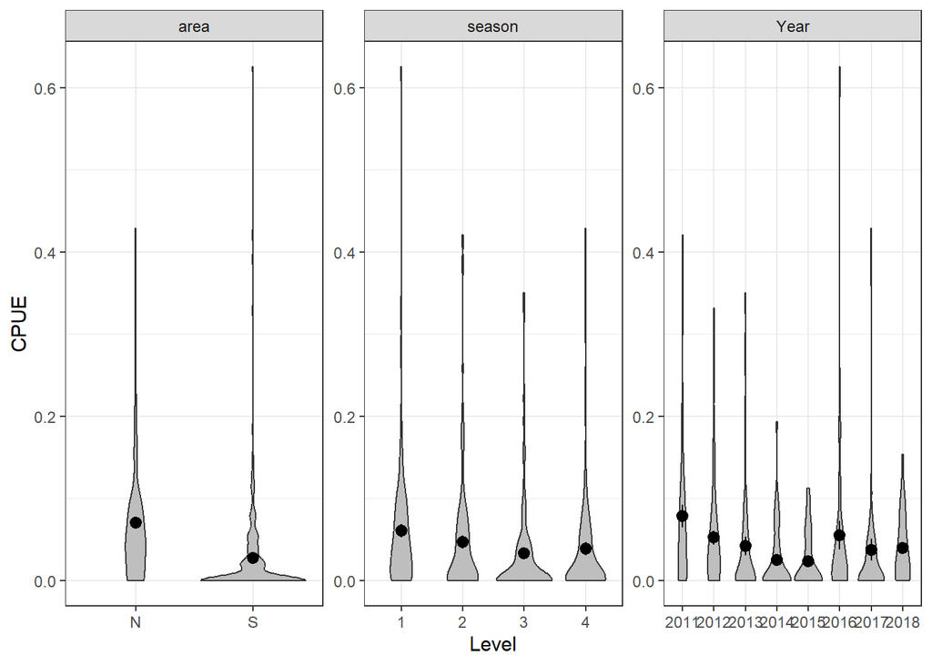

Figure 15. Observed CPUE of Blue marlin by factor levels.

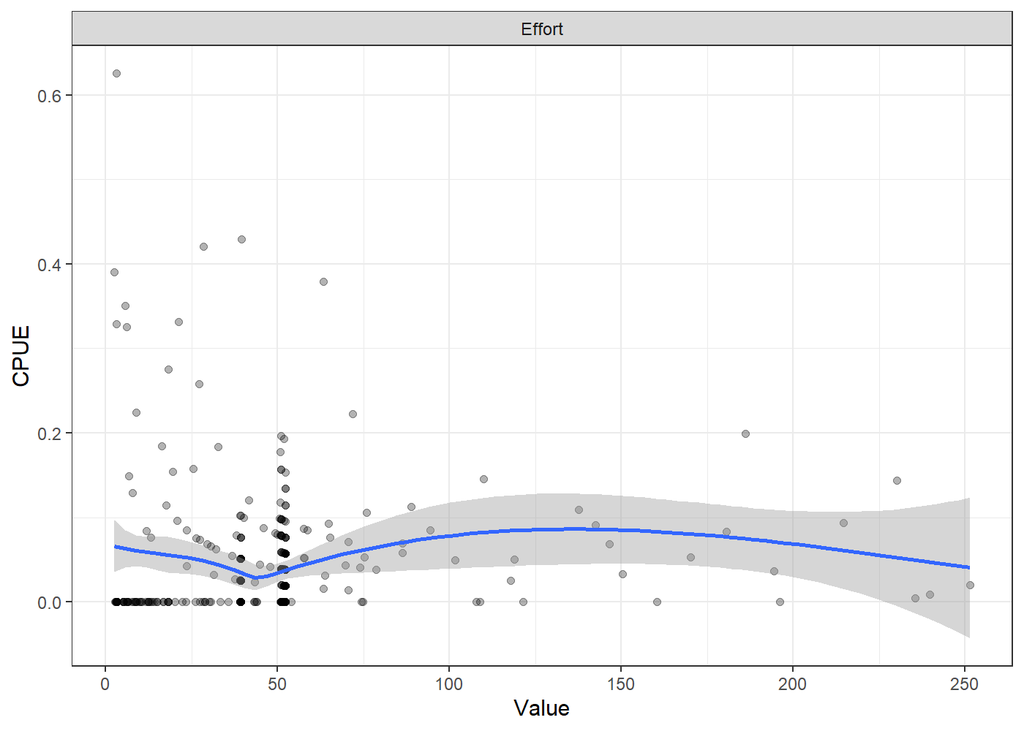

Figure 16. Observed CPUE of Blue marlin across numerical variables.